# Dice_Throw

You are rolling two die simultaneously and noting the number of dots. Calculate p, the probability of getting the same number of dots from both the die. (Repeat trials for 50, 500, 5000 times)

```python
import random as rn
choice='Y'
while choice=='Y' or choice=='y':
	n=int(input('Enter no of experiments : '))
	count=0
	for i in range(n):
		v1=rn.randint(1,7)
		v2=rn.randint(1,7)
		if v1==v2:
			count+=1
	p=count/n
	print('The probability is :',p)
	choice=input('Do you want to continue y/n ? :')
```

```
The probability is : 0.2
```

```
The probability is : 0.186
```

```
The probability is : 0.146
```

```
The probability is : 0.1518
```

```
The probability is : 0.142878
```

# Gaussian_Probability_1

A sample of dry battery cells tested to find the length of life produced the following result: xmean = 12 hours, standard deviation = 3 hours. Assuming that the data are normally distributed, what percentage of battery are expected to have life between 10-14 hours? (Method 1)

```python
import numpy.random as rn

N=int(input('Enter size of sample of battery cells : '))
low,up=10,14
u=rn.normal(loc=12,scale=3,size=N)
n=len([u[i] for i in range(N) if u[i]<14 and u[i]>10])

print('The percentage of cells with battery life between',low,'and',up,'hours is :',n/N*100,'%')
```

```
The percentage of cells with battery life between 10 and 14 hours is : 50.0 %
```

# Gaussian_Probability_2

A sample of dry battery cells tested to find the length of life produced the following result: xmean = 12 hours, standard deviation = 3 hours. Assuming that the data are normally distributed, what percentage of battery are expected to have life between 10-14 hours? (Method 2)

```python
import numpy as np
import matplotlib.pyplot as plt
from scipy.integrate import quad

def f(x):
	return 1/(np.sqrt(2*np.pi)*sig)*np.exp((-(x-mu)**2)/(2*sig**2))

mu,sig=12,3
low,up=10,14

print('The percentage of cells with battery life between',low,'and',up,'hours is :',quad(f,low,up)[0]*100,'%')
```

```
The percentage of cells with battery life between 10 and 14 hours is : 49.501492490615426 %
```

# CLT

Normal distribution (gaussian variate) from die throwing population and exponential distribution (Method 1)

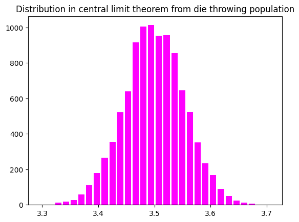

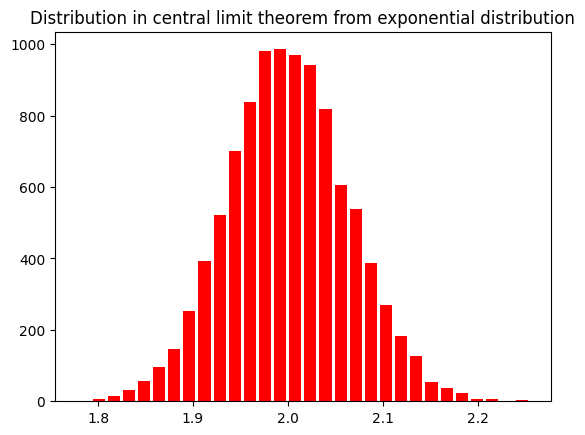

```python
import numpy as  np
import numpy.random as rn
import matplotlib.pyplot as plt
n=int(input('Enter sample size : '))
f=lambda n: np.mean(rn.randint(1,7,n))		#The size of n determines how closer will be the several means in each trial i.e it reduces s.d and makes the histogram smoother
g=lambda n: np.mean(rn.exponential(2,n))
x,y=[],[]
for i in range(10000):						#The size of iteration determines how many samples of mean to be generated i.e increases scope of n and makes the histogram uniformly placed
	x.append(f(n))
	y.append(g(n))

plt.figure()
plt.title('Distribution in central limit theorem from die throwing population')
plt.hist(x,bins=30,rwidth=0.8,color='magenta')

plt.figure()
plt.title('Distribution in central limit theorem from exponential distribution')
plt.hist(y,bins=30,rwidth=0.8,color='red')


plt.show()
```

# CLT

Normal distribution (gaussian variate) from die throwing population and exponential distribution (Method 2)

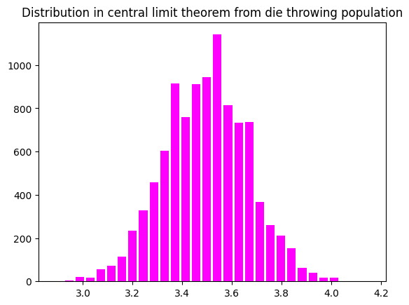

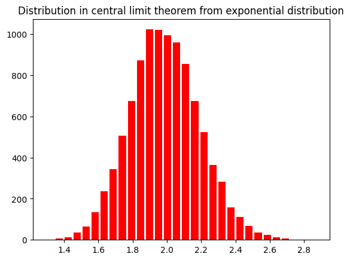

```python
import numpy as  np
import numpy.random as rn
import matplotlib.pyplot as plt
n=int(input('Enter sample size : '))
f=rn.randint(1,7,n)
g=rn.exponential(2,n)
x,y=[],[]
for i in range(10000):
	x.append(np.mean(rn.choice(f,100)))
	y.append(np.mean(rn.choice(g,100)))

plt.figure()
plt.title('Distribution in central limit theorem from die throwing population')
plt.hist(x,bins=30,rwidth=0.8,color='magenta')

plt.figure()
plt.title('Distribution in central limit theorem from exponential distribution')
plt.hist(y,bins=30,rwidth=0.8,color='red')

plt.show()
```

# CLT

Normal distribution sampling from a single die throwing population (Method 1)

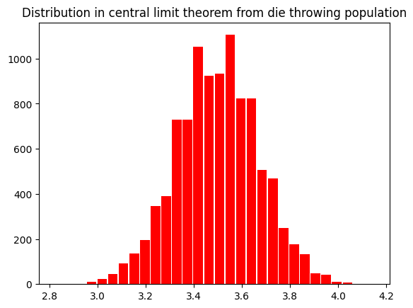

```python
import numpy as  np
import numpy.random as rn
import matplotlib.pyplot as plt

N=100000000				#size of population
R=rn.randint(1,7,N)
size=100				#size of each sample from the population
number=N/size

P=[];M=[];j=0
for i in range(0,int(number),size):
	P.append(R[0+i:size+i])
	j+=1
	M.append(np.mean(P[j-1]))

plt.title('Distribution in central limit theorem from die throwing population')
plt.hist(M,bins=30,rwidth=0.9,color='red')
plt.show()
```

# CLT

Normal distribution sampling from a single die throwing population (Method 2)

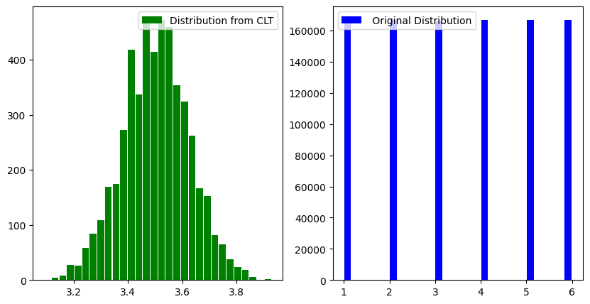

```python
import numpy.random as rn
import numpy as np
import matplotlib.pyplot as plt

N=1000000					#Population size
P=rn.randint(1,7,N)			#Population having elements 1,2,3,4,5,6 randomly stored in an array

size=200					#Size of each sample to be generated
number=N/size				#No. of samples generated from the population

def index(n):
	position=[rn.randint(0,N-1) for j in range(size)]		#Storing index values from the whole size of population randomly generated for a sample
	sample=[P[k] for k in position]							#Creating a sample picking  from the population corresponding to the random index postions for the defined sample size
	return np.mean(sample)									#returning mean of the sample

M=[index(i) for i in range(int(number))]					#Creating many samples for defined sample number to store the mean values of each such samples

fig=plt.figure(figsize=(10,5),dpi=100)
plt.subplot(1,2,1)
plt.hist(M,bins=30,rwidth=0.9,color='green',label='Distribution from CLT')
plt.legend()
plt.subplot(1,2,2)
plt.hist(P,bins=30,rwidth=0.9,color='blue',label=' Original Distribution')
plt.legend()
plt.show()
```

# Linear congruential method and auto-correlation function of a given time series

```
Random Number Series :

[3.00000000e+00 9.00000000e+00 2.10000000e+01 ... 4.44753203e+09
 8.89506406e+09 7.79012812e+09]

Normalised Random Number Series :

[3.00000000e-10 9.00000000e-10 2.10000000e-09 ... 4.44753203e-01
 8.89506406e-01 7.79012812e-01]
```

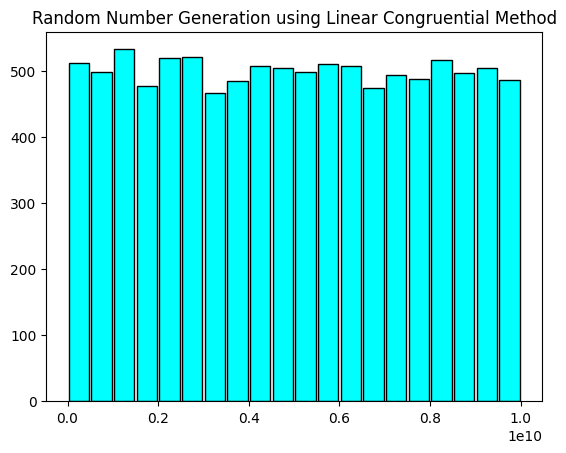

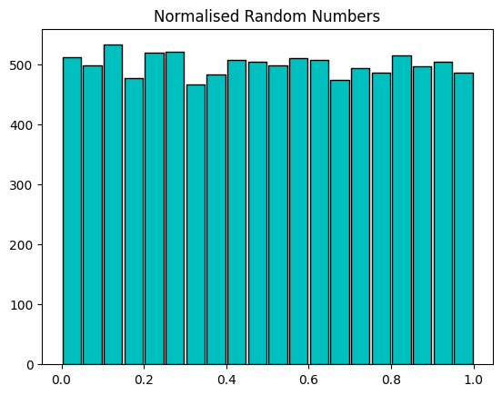

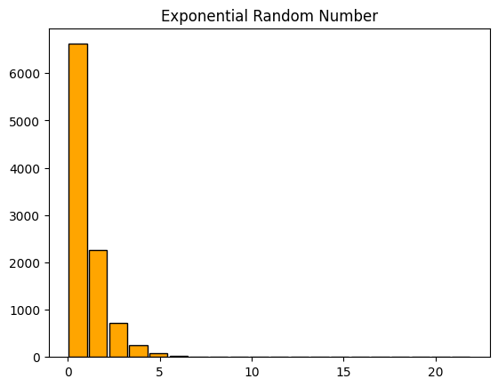

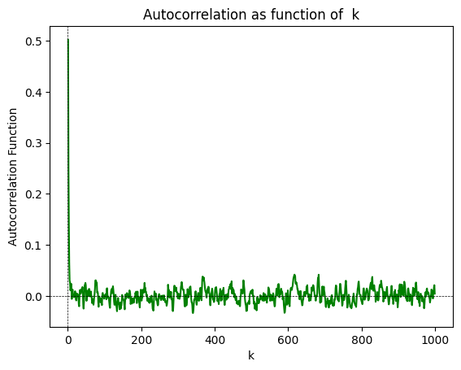

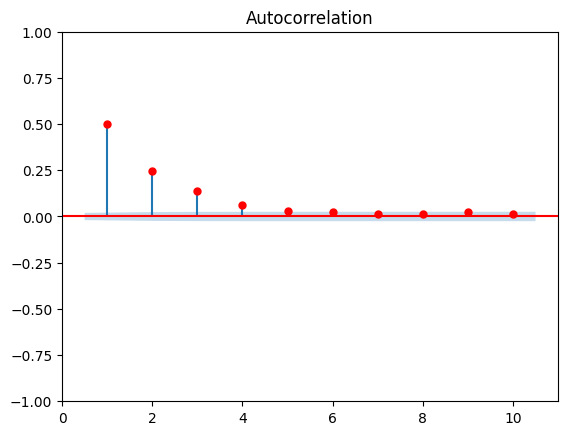

```python
import numpy as np
import matplotlib.pyplot as plt
from statsmodels.graphics import tsaplots

#LCM
x0=eval(input('Enter the seed : '))
a=eval(input('Enter the multiplier : '))
c=eval(input('Enter the increment : '))
N=eval(input('Enter the number of random numbers to generate : '))
m=eval(input('Enter the modulus : '))
X=np.zeros(N+1)
X[0]=x0
for i in range(N):
	X[i+1]=(a*X[i]+c)%m
Y=X[1:]							#x0 is predefined, hence excluded
U=Y/m
print()
print('Random Number Series : \n')
print(Y)
print()
print('Normalised Random Number Series : \n')
print(U)

plt.figure()
plt.title('Random Number Generation using Linear Congruential Method')
plt.hist(Y,bins=20,rwidth=0.9,edgecolor='black',color='cyan')
plt.show()

plt.figure()
plt.title('Normalised Random Numbers')
plt.hist(U,bins=20,rwidth=0.9,edgecolor='black',color='c')
plt.show()

plt.figure()
plt.title('Exponential Random Number')
plt.hist(-np.log(U),bins=20,rwidth=0.9,edgecolor='black',color='orange')
plt.show()

#ACF
ubar=np.mean(U)
def c(k):
	return (np.sum([(U[i]-ubar)*(U[i+k]-ubar) for i in range(N-k)]))/N
def r(k):
	return c(k)/c(0)

corr=[]
for k in range(1,N//10):
	corr.append(r(k))

plt.figure()
plt.title('Autocorrelation as function of  k')
plt.plot(range(1,N//10),corr,'-',color='green')
plt.axhline(color='black',lw=0.5,ls='--')
plt.axvline(color='black',lw=0.5,ls='--')
plt.xlabel('k')
plt.ylabel('Autocorrelation Function')
plt.show()

#Correlogram
fig=tsaplots.plot_acf(U,lags=10,zero=False,color='red',title='Autocorrelation')
```

# Generating exponential variates from uniform variate using transformation

(Method 1)

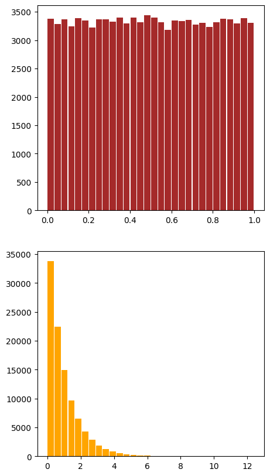

```python
import numpy as np
import numpy.random as rn
import matplotlib.pyplot as plt

x=rn.random(100000)
y=-np.log(x)

fig=plt.figure(figsize=(5,10),dpi=100)
plt.subplot(2,1,1)
plt.hist(x,bins=30,rwidth=0.9,color='brown')

plt.subplot(2,1,2)
plt.hist(y,bins=30,rwidth=0.9,color='orange')

plt.show()
```

# Generating exponential variates from uniform variate using transformation

(Method 2)

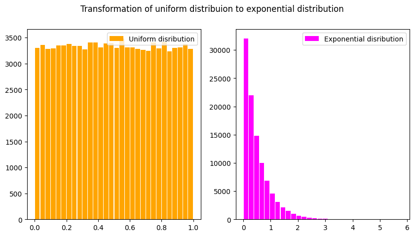

```python
import numpy.random as rn
import numpy as np
import matplotlib.pyplot as plt

N=100000
U=rn.uniform(0,1,N)
X=[]
m=np.mean(U)
for i in U:
	X.append(-(m*np.log(1-i)))

fig=plt.figure(figsize=(10,5),dpi=100)
plt.suptitle('Transformation of uniform distribuion to exponential distribution')

plt.subplot(1,2,1)
plt.hist(U,bins=30,rwidth=0.9,color='orange',label='Uniform disribution')
plt.legend()

plt.subplot(1,2,2)
plt.hist(X,bins=30,rwidth=0.9,color='magenta',label='Exponential disribution')
plt.legend()

plt.show()
```